# QualitativeActivityRecognitionProject

Steve Nelson

September 25, 2015

## Qualitative Activity Recognition

#### Synopsis

The goal of the project is to predict which of five techniques a participant applies when performing a bicep curl. One technique of performance is correct while the other four techniques were incorrect.

There are four important elements in using data to adequately predict such an outcome. The first is understanding and **exploring the data**, how it was derived and what it says and doesn’t or can’t say. The next is the **preprocessing the data** based on our understanding of the data. These are very important, and in the case of this dataset more important than the **algorithm** constructed to do the prediction. Finally, that **prediction** needs to be understood in the context of interpretability, accuracy and error.

The data exploration and subsequent preprocess of the data have been very important. Holes were discovered in the data and were filled through preprocessing. Whole sections of data that were zeroed out were imputed. All of the data was centered and scaled.

The alogithm used in this analysis was the “Random Forest” method in the caret package. The data was cross-validated via 10 fold cross-validation run five times.

The resulting prediction was over 99.34 percent accurate on training data and 99.25 percent accurate on the test data. The testing data was surprisingly close to having less error than the training data. Subtracting there errors from 100 percent, the measure of the in-sample error is 0.66 percent while the out of sample error is just 0.75 percent.

When using the prediction algorithm developed here, the 20 test cases were all predicted correctly.

Thanks are expressed to the developer of this data. Source: “Qualitative Activity Recognition of Weight Lifting Exercises”, Eduardo Velloso, Lancaster University,Lancaster, UK; Andreas Bulling, Max Planck Institute for Informatics Saarbrücken, Germany, Hans Gellersen, Lancaster University,Lancaster, UK, Wallace Ugulino, Pontifical Catholic University of Rio de Janeiro Rio de Janeiro, Brazil, Hugo Fuks,Pontifical Catholic University of Rio de Janeiro, Rio de Janeiro, Brazil.

## Purpose of Research

The purpose of this project is to predict which flaws test subjects have in their technique for bicep curls. The researchers have defined a class of motions that result in properly executed curls and have also identified sets of motions where curls are executed improperly. The “classe” variable in the data set identifies what you might call the quality of the performance. A curl can be preformed:

classe “A” Correctly

classe “B” Incorrectly: throwing elbows to the front

classe “C” Incorrectly: lifting the dumbbell only halfway

classe “D” Incorrectly: lowering the dumbbell only halfway

classe “E” Incorrectly: throwing the hips to the front

Participants were supervised by an experienced weightlifter to make sure the execution complied to the techniques they were supposed to simulate. The exercises were performed by six male participants aged between 20-28 years, with little weight lifting experience.

### Detection of Mistakes in Exercises

The goal of experiment was to assess whether mistakes could be detected in weight-lifting exercises by using activity recognition techniques. Six users were measured with wearable sensors performing the same bicep curls activity correctly and with the set of four common mistakes. Participants were asked to perform one set of 10 repetitions of the Unilateral Dumbbell Biceps Curl with the five different techniques.

Four 9-degree of freedom Razor inertial measurement units (IMUs) were used. These sensors were mounted in the user’s glove, armband, lumbar belt and dumbbell. Data collected from these sensors were raw accelerometer, gyroscope and magnetometer readings and calculated features on the Euler angles (roll, pitch and yaw), as well. “[Euler Angles,https://en.wikipedia.org/wiki/Euler_angles]”

## Data Exploration

The data frame was 19,622 rows by 160 columns. In general, the rows refered to the sensor observations at a specific point in time as measured in tiny fractions of a second within an observation window. The time measures were grouped into 858 windows. The variables related to the windows, date, time and timestamp are not necessary for the model building as the model will not focus on predicting a window but on an individual moment of time.

```
##
##       adelmo carlitos charles eurico jeremy pedro   Sum
##   A     1165      834     899    865   1177   640  5580
##   B      776      690     745    592    489   505  3797
##   C      750      493     539    489    652   499  3422
##   D      515      486     642    582    522   469  3216
##   E      686      609     711    542    562   497  3607
##   Sum   3892     3112    3536   3070   3402  2610 19622
```

#### Which Variables to Keep as Predictors

There were thirty-eight measures for each of the four sensors, arm, belt, forearm and dumbbell. Thirteen measures for each of the four sensors appear to be raw moment-to-moment data while twenty-five measures are summary measures for each of these data variables. These summary values are only calculated once over the length of the observation window. Consequently, there were many missing values or na’s in these columns. Since they are not raw data, these 100 measures will not be included in the evaluation data set.

To summarise, the variables that will be kept include the thirteen raw measures for each of the four sensors and the classe variable, for a total of 53 variables. Their names are shown below.

```
##  [1] "roll_belt"            "pitch_belt"           "yaw_belt"
##  [4] "total_accel_belt"     "gyros_belt_x"         "gyros_belt_y"
##  [7] "gyros_belt_z"         "accel_belt_x"         "accel_belt_y"
## [10] "accel_belt_z"         "magnet_belt_x"        "magnet_belt_y"
## [13] "magnet_belt_z"        "roll_arm"             "pitch_arm"
## [16] "yaw_arm"              "total_accel_arm"      "gyros_arm_x"
## [19] "gyros_arm_y"          "gyros_arm_z"          "accel_arm_x"
## [22] "accel_arm_y"          "accel_arm_z"          "magnet_arm_x"
## [25] "magnet_arm_y"         "magnet_arm_z"         "roll_dumbbell"
## [28] "pitch_dumbbell"       "yaw_dumbbell"         "total_accel_dumbbell"
## [31] "gyros_dumbbell_x"     "gyros_dumbbell_y"     "gyros_dumbbell_z"
## [34] "accel_dumbbell_x"     "accel_dumbbell_y"     "accel_dumbbell_z"
## [37] "magnet_dumbbell_x"    "magnet_dumbbell_y"    "magnet_dumbbell_z"
## [40] "roll_forearm"         "pitch_forearm"        "yaw_forearm"
## [43] "total_accel_forearm"  "gyros_forearm_x"      "gyros_forearm_y"
## [46] "gyros_forearm_z"      "accel_forearm_x"      "accel_forearm_y"
## [49] "accel_forearm_z"      "magnet_forearm_x"     "magnet_forearm_y"
## [52] "magnet_forearm_z"     "classe"
```

## Data Preprocessing

The first step in preprocessing was to eliminate the variables that weren’t of value to the modeling, the seven identifier variables at the start of the data set and the 100 other unnecessary variables. This was done by simple subsetting.

Next, there was evidence of systematic flaws in the raw data. This is evident in the heatmap below. In particular, values for Jeremy and Adelmo in several variables suggest sensor failure or transcription error.

These zero values are modified with the “sample function” which calculates the mean and standard deviation of the non-missing values and applies them to the values that are zero.

Finally, the preProcess function in caret is used to center and scale all of the variables.

### Heatmap Highlighting Zero Values in Gold

Many zero values in variables show no distinct pattern but there is a definite pattern to several variables.

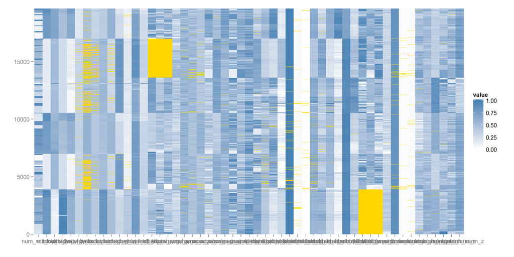

As can be seen from the table below, roll_forearm, pitch_forearm, and yaw_forearm have large number of zero values as do roll_arm, pitch_arm and yaw_arm. The heatmap above shows a consistent string of zero values. On the heatmap, these six are shown as the longer strings of gold. The location differences on the heatmap reflect different users, creating a plaid-like visual effect. The less consistent strings of gold zero values are evident in three user levels locations and reflect the higher number of zeros from gyros-belt x, y and z. Other zero values seem more or less random.

```
##                      pedro jeremy eurico charles carlitos adelmo
## user_name                0      0      0       0        0      0
## num_window               0      0      0       0        0      0
## roll_belt                0      3      1       0        1      0
## pitch_belt               0      0      1       0        0      0
## yaw_belt                 0      0      0       3        0      0
## total_accel_belt         0      0      1       0        2      0
## gyros_belt_x             0    312    297      48      342     40
## gyros_belt_y           130   1643   1222       9     1693     22
## gyros_belt_z             2    871    376      11      486     21
## accel_belt_x             0     13     12       3        4      0
## accel_belt_y             0    350     80       0      117      0
## accel_belt_z             0      2      2       0       12      0
## magnet_belt_x          120      1      2       5      222      0
## magnet_belt_y            0      0      0       0        0      0
## magnet_belt_z            0      0      0       0        0      0
## roll_arm                 0   3402      0       0        0      0
## pitch_arm                0   3402      0       1        0      0
## yaw_arm                  0   3402      0       0        0      0
## total_accel_arm          0      0      0       0        0      0
## gyros_arm_x              5    236     71       6      180     18
## gyros_arm_y             21    211    104      44      113     22
## gyros_arm_z             57    170     95       8      192      2
## accel_arm_x             22     14      4       7        4     10
## accel_arm_y             21      7      6       1       11     15
## accel_arm_z              2      6      7      17       12     14
## magnet_arm_x             2      0      2       5        0      0
## magnet_arm_y             0      2      1       6        1      5
## magnet_arm_z             0      3      1       0        1      2
## roll_dumbbell           47      0     20      37       30      0
## pitch_dumbbell          13      0     40      63      194      2
## yaw_dumbbell             0      0     24      43       47      0
## total_accel_dumbbell     0      0      5      18        5      0
## gyros_dumbbell_x        10     12     56     146      311     79
## gyros_dumbbell_y        58     50     88      54      151    134
## gyros_dumbbell_z        28     22    158     123      181     87
## accel_dumbbell_x        13      0     40      63      194      2
## accel_dumbbell_y        47      0     20      35       27      0
## accel_dumbbell_z         0      0     23      43       44      0
## magnet_dumbbell_x        0      0      1       1        1      1
## magnet_dumbbell_y        0      0      0       0        0      0
## magnet_dumbbell_z        2     14      0      18       33     22
## roll_forearm             0      0      0       2        0   3892
## pitch_forearm            0      1      0       0        0   3892
## yaw_forearm              0      0      0       0        0   3892
## total_accel_forearm      0      0      0       7        0      0
## gyros_forearm_x         25    214     57      56      168      3
## gyros_forearm_y         30    187      8      25      125      8
## gyros_forearm_z         50    157     26      71      119     22
## accel_forearm_x          8      4      5       6        6     12
## accel_forearm_y          0      4      1      22        0      3
## accel_forearm_z          0      0      0      43        0     33
## magnet_forearm_x         0      5      1       1        0      4
## magnet_forearm_y         1      1      0       0        0      0
## magnet_forearm_z         0      1      1       3        1      3
## classe                   0      0      0       0        0      0
```

## Modeling Algorithm:

The modeling is done with the “rf” method in the train function of caret. Rpart was tried but with not enough accuracy. TrainControl was set a method=“repeatedcv” with ten folds and 5 repeats. Having five repeats provided a better picture of error. Ten folds allowed some bump in accuracy.

```r
modFit<- train(classe ~ .,method="rf", preProcess=c("center", "scale"),trControl=trainControl(method = "repeatedcv", number = 10, repeats=5), data=training, importance=TRUE)
varImp(modFit)
```

```
## rf variable importance
##
##   variables are sorted by maximum importance across the classes
##   only 20 most important variables shown (out of 52)
##
##                          A      B     C      D       E
## roll_belt            70.13 71.419 76.05 69.467 100.000
## pitch_forearm        56.18 69.495 91.11 56.369  57.062
## pitch_belt           24.57 88.303 59.75 45.195  37.035
## magnet_dumbbell_y    64.93 60.246 75.57 59.728  50.070
## magnet_dumbbell_z    71.24 53.101 67.69 46.462  47.431
## yaw_belt             62.35 55.823 59.98 63.115  37.980
## accel_forearm_x      16.95 36.438 33.03 47.540  32.055
## roll_forearm         45.48 35.244 42.01 29.430  31.718
## yaw_arm              36.95 23.464 24.72 27.756  15.767
## gyros_belt_z         21.76 26.152 25.62 19.032  36.647
## accel_dumbbell_y     30.21 29.136 34.89 26.234  27.440
## gyros_dumbbell_y     30.94 24.408 33.90 22.120  20.239
## magnet_belt_x        11.28 30.353 23.37 13.093  25.180
## accel_dumbbell_z     20.71 29.694 21.14 27.938  30.258
## magnet_belt_y        13.54 28.478 24.19 16.753  21.728
## gyros_arm_y          20.15 28.055 20.61 25.681  19.334
## magnet_belt_z        17.21 27.837 23.06 25.265  24.347
## gyros_belt_x         27.76  9.941 14.44  5.412   9.503
## roll_dumbbell        15.49 27.298 17.62 17.888  23.959
## total_accel_dumbbell 12.64 26.464 16.26 22.953  26.490
```

```r
#print(modFit)
modFit$finalModel
```

```
##
## Call:
##  randomForest(x = x, y = y, mtry = param$mtry, importance = TRUE)
##                Type of random forest: classification
##                      Number of trees: 500
## No. of variables tried at each split: 27
##
##         OOB estimate of  error rate: 0.54%
## Confusion matrix:
##      A    B    C    D    E  class.error
## A 4181    1    1    1    1 0.0009557945
## B   21 2821    6    0    0 0.0094803371
## C    0   12 2548    7    0 0.0074016362
## D    0    0   20 2389    3 0.0095356551
## E    0    0    3    4 2699 0.0025868441
```

```r
rsamp<-modFit$resample
reslt<-modFit$results

#sources http://topepo.github.io/caret/training.html caret primer
```

Here is the accuracy and the in-sample error rate estimate.

```r
mean(rsamp$Accuracy)
```

```
## [1] 0.9933825
```

```r
1-mean(rsamp$Accuracy)
```

```
## [1] 0.006617461
```

```r
#sd(rsamp$Accuracy)
#rsamp[order(rsamp$Resample)]
```

## Results

The results show that we can predict the technique of a subject doing a bicep curl with high accuracy. It remains to be seen whether the model can be scaled up beyond these six subjects. however.

```
## Confusion Matrix and Statistics
##
##           Reference
## Prediction    A    B    C    D    E
##          A 1394    9    0    1    0
##          B    1  937    3    1    1
##          C    0    3  849    7    4
##          D    0    0    3  794    3
##          E    0    0    0    1  893
##
## Overall Statistics
##
##                Accuracy : 0.9925
##                  95% CI : (0.9896, 0.9947)
##     No Information Rate : 0.2845
##     P-Value [Acc > NIR] : < 2.2e-16
##
##                   Kappa : 0.9905
##  Mcnemar's Test P-Value : NA
##
## Statistics by Class:
##
##                      Class: A Class: B Class: C Class: D Class: E
## Sensitivity            0.9993   0.9874   0.9930   0.9876   0.9911
## Specificity            0.9972   0.9985   0.9965   0.9985   0.9998
## Pos Pred Value         0.9929   0.9936   0.9838   0.9925   0.9989
## Neg Pred Value         0.9997   0.9970   0.9985   0.9976   0.9980
## Prevalence             0.2845   0.1935   0.1743   0.1639   0.1837
## Detection Rate         0.2843   0.1911   0.1731   0.1619   0.1821
## Detection Prevalence   0.2863   0.1923   0.1760   0.1631   0.1823
## Balanced Accuracy      0.9982   0.9929   0.9948   0.9930   0.9954
```

This is the prediction accuracy of the testing sets against the model results. 0.9924551. The out-of-sample error is one minus this number or 0.0075449.

```
##  [1] B A B A A E D B A A B C B A E E A B B B
## Levels: A B C D E
```

The results of the model against the test set are 20 out of twenty.